# Advanced Empirical Finance: Topics and Data Science

Neural networks and learning the SDF

Stefan Voigt

University of Copenhagen and Danish Finance Institute (DFI)

Spring 2027

## Today

- Neural networks: a short introduction
- A network for the returns of the zoo
- Learning the SDF directly: Chen, Pelger & Zhu (2024)
- Flexibility against economic structure

# Neural networks

## Whiteboard: a feed-forward network

Build a flexible function $g(z)$ from simple pieces: each **neuron** takes a weighted sum of its inputs and passes it through a nonlinear **activation**

$$h^{(1)} = \sigma\big(W^{(1)} z + c^{(1)}\big), \quad h^{(2)} = \sigma\big(W^{(2)} h^{(1)} + c^{(2)}\big), \quad g(z) = w' h^{(L)} + c$$

- $\sigma(x) = \max(x, 0)$ (ReLU) or the logistic function. Without $\sigma$, the network would be linear regression
- With enough neurons, a network approximates any smooth function. The price: many parameters, here 46 already for one layer of 5 neurons and 7 inputs

## Training a network

- **Loss:** the mean squared forecast error, as for OLS. No closed form: **gradient descent** moves all weights a small step against the gradient of the loss
- **Backpropagation:** the chain rule gives the gradients of all layers in one backward pass; mini-batches of observations make each step cheap
- **Regularization**, because the network can fit the noise:
  - **weight decay:** a ridge penalty on the weights
  - **early stopping:** stop when the loss in a validation sample rises; the validation sample also chooses the penalty
  - **dropout:** switch off random neurons during training
  - **ensembles:** average networks from different random starts
- Gu, Kelly & Xiu (2020) use all of them; their best networks have three or four layers

## A network for the returns of the zoo

- R
- Python

```r
features <- c("ret_lag_1", "momentum_12", macro_names)
centers <- colMeans(train[features])
input_sd <- apply(train[features], 2, sd)
scale_inputs <- function(data) scale(as.matrix(data[features]), centers, input_sd)
ret_sd <- sd(train$ret)  # returns in units of their volatility, so that the decay has a scale

fit_network <- function(data, decay, seed) {
  set.seed(seed)
  nnet(scale_inputs(data), data$ret / ret_sd, size = hidden_units, decay = decay,
       linout = TRUE, maxit = 500, trace = FALSE)
}
# Weight decay chosen on the validation years 1995-1999, then an ensemble of five networks
fitting <- filter(train, date < validation_start)
validation <- filter(train, date >= validation_start)
validation_mse <- map_dbl(decays, \(decay) {
  mean((validation$ret - predict(fit_network(fitting, decay, 1), scale_inputs(validation)) * ret_sd)^2)
})
decay <- decays[which.min(validation_mse)]
network_forecast <- map(seq_len(n_networks), \(seed) {
  as.vector(predict(fit_network(train, decay, seed), scale_inputs(panel))) * ret_sd
}) |>
  reduce(`+`) / n_networks
```

```python
features = ["ret_lag_1", "momentum_12", *macro_names]
centers = train.select(features).mean().to_numpy()
input_sd = train.select(features).std().to_numpy()
scale_inputs = lambda data: (data.select(features).to_numpy() - centers) / input_sd
ret_sd = train["ret"].std()  # returns in units of their volatility, so that the decay has a scale


def fit_network(data, decay, seed):
    return MLPRegressor(hidden_layer_sizes=(5,), activation="logistic", solver="lbfgs", alpha=decay,
                        max_iter=500, random_state=seed).fit(scale_inputs(data), data["ret"].to_numpy() / ret_sd)


# Weight decay chosen on the validation years 1995-1999, then an ensemble of five networks
fitting, validation = train.filter(pl.col("date") < date(1995, 1, 1)), train.filter(pl.col("date") >= date(1995, 1, 1))
validation_mse = [np.mean((validation["ret"].to_numpy() - fit_network(fitting, d, 1).predict(scale_inputs(validation)) * ret_sd) ** 2)
                  for d in [1, 3, 10, 30, 100, 300, 1000]]
decay = [1, 3, 10, 30, 100, 300, 1000][int(np.argmin(validation_mse))]
network_forecast = np.mean([fit_network(train, decay, seed).predict(scale_inputs(panel)) * ret_sd
                            for seed in range(1, 6)], axis=0)
```

## The network’s forecasts

One hidden layer of 5 logistic neurons, weight decay 300 (chosen on 1995–1999), five networks averaged. Out-of-sample $R^2$ 1.24% (OLS: 0.65%); as a portfolio with the forecasts as expected returns (lecture 13): Sharpe ratio 1.36 in the test sample. `nnet()` and scikit-learn (same penalty scale) start from different random weights, so their networks differ a little

# Learning the SDF

## Whiteboard: SDF weights that depend on the state

Lecture 11: constant weights, $m = 1 - b'(F - E[F])$; written without centring, $M_{t+1} = 1 - b'F_{t+1}$, the weights are proportional to the same $\Sigma^{-1}\mu$. Now each anomaly’s weight depends on what we know at $t$: $M_{t+1} = 1 - \sum_i \omega(I_{t}, z_{i,t})\, F_{i,t+1}$

$$E\big[M_{t+1} F_{i,t+1} \mid I_t\big] = 0 \qquad \Longleftrightarrow \qquad E\big[M_{t+1} F_{i,t+1}\, g(I_t, z_{i,t})\big] = 0 \ \text{ for all } g$$

- The conditional moments hold for every **instrument** $g$: every managed portfolio $F_{i,t+1}\, g(\cdot)$ must be priced, too
- A network $\omega(\cdot)$ for the weights, estimated by minimizing the squared pricing errors of these moments

## The adversary

- Infinitely many instruments $g$: which ones should the SDF price? Chen, Pelger & Zhu (2024): let a **second network** choose them
- The adversary picks the managed portfolios with the **largest pricing errors**; the SDF network then learns to price them. A game, like a generative adversarial network:

$$\min_{\omega} \ \max_{g} \ \frac{1}{N}\sum_i \Big\| E\big[M_{t+1} F_{i,t+1}\, g(I_t, z_{i,t})\big] \Big\|^2$$

- Their result on US stocks: an SDF with an out-of-sample Sharpe ratio far above linear factor models, using the macro state and characteristics

## Chen–Pelger–Zhu light on the zoo

```python
def network(n_out, hidden, dropout):
    return nn.Sequential(
        nn.Linear(n_inputs, hidden), nn.ReLU(), nn.Dropout(dropout),
        nn.Linear(hidden, hidden), nn.ReLU(), nn.Dropout(dropout),
        nn.Linear(hidden, n_out),
    )


def pricing_loss(weights, instruments, months):
    """Mean squared pricing error of the moments E[M F_i g_j] = 0."""
    sdf = 1 - (weights * returns).sum(dim=1)
    moments = (sdf[:, None, None] * returns[:, :, None] * instruments)[months].mean(dim=0)
    return (moments ** 2).sum(dim=1).mean()
```

- **Inputs of each anomaly:** last month’s return, factor momentum, its historical mean, its loadings on the first 10 principal components; optionally the macro state
- **Training** 1974–1994, **validation** 1995–1999 (early stopping and the choice of the setting), test from 2000. PyTorch only: `lecture-slides/factor-zoo/cpz_light.py`, 72 settings × 9 networks, 2 h 14 min on 64 UCloud cores

## What the networks earn

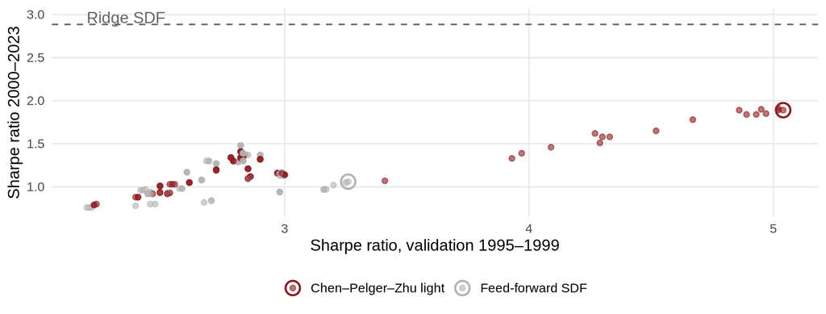

- Each dot is one of the 72 settings; circles: the setting chosen on the validation sample. The adversary helps: 1.89 against 1.06 without it
- For Chen–Pelger–Zhu light, the validation Sharpe ratio predicts the test Sharpe ratio (correlation 0.91). But no setting reaches the ridge SDF

## Flexibility against economic structure

- **Nagel (2021):** returns are noisy and samples are short; machine learning in asset pricing works best with economic restrictions, such as a prior that rules out implausibly high Sharpe ratios
- **Our scoreboard:** 158 anomalies, 27 years of estimation data. The ridge SDF has one tuning parameter and an economic prior; the networks have thousands of parameters and only the data
- Gu, Kelly & Xiu and Chen, Pelger & Zhu use tens of thousands of stocks and decades of data: there, flexibility pays

The more data, the more flexibility can pay; with little data, economic structure wins

## Scoreboard

| Portfolio | Inputs | Sharpe ratio, estimation | Sharpe ratio 2000–2023 |
| --- | --- | --- | --- |
| Ridge (prior on Sharpe ratios) | 158 anomalies | 12.92 | 2.89 |
| Forecasts: OLS | 7 predictors | 8.68 | 1.13 |
| Forecasts: neural network | 7 predictors | 9.23 | 1.36 |
| Feed-forward SDF | Features of each anomaly | 3.63 | 1.06 |
| Chen–Pelger–Zhu light | Features of each anomaly | 5.71 | 1.89 |

- The SDF networks: setting chosen on the validation sample 1995–1999, ensembles of 9 networks. The rows of lectures 10 to 13 stay on the scoreboard
- **Lecture 15:** what all these portfolios trade, and what remains after costs